# Regression Models Course Project : The Effects of Transmission Type on MPG

Chris Gomes

July 22, 2016

## Executive Summary

We study the `mtcars` data set to examine the relationships between several variables (e.g. transmission type, displacement, weight, and cylinder number) and miles per gallon (MPG).

We answer two questions:

- Is an automatic or manual transmission better for MPG?
- How different is the mpg between automatic and manual transmissions?

We determine that there is a difference in mpg for automatic and manual transmissions with manual transmissions giving an increase of 1.8 miles per gallon over automtic transmissions.

## Exploratory Analysis

We load the data set and and try to determine which variables are statistically significant. Looking at the internal structure of `mtcars`, we see that the variables: cyl, vs, am, gear, and carb are categorical. So we convert them using factor().

See figure 1 in the appendix for exploratory analysis and visualizations.

Since the goal of this analysis is to explore potential relationships between mpg and transmission type, we look at a box plot and note that there is a difference (see figure 2).

## Regression Analysis

### Simple Linear Regression

First we look at a simple liinear model with `am` as the predictor of `mpg`.

```r
simple <- lm(mpg ~ am, data = mtcars)
```

```r
summary(simple)
```

[output not shown]

### Generalized Linear Models

Next, we look at a model using all variables as predictors of mpg, then we refine this naive initial model using the `step` method to select the best model.

```r
initial <- lm(mpg ~ ., data = mtcars)
best <- step(initial, direction = "both")
```

```r
summary(best)
```

[output not shown]

We see that the best model uses cyl, hp, wt, and am. Since the adjusted R-squared is approximately 0.84, we conclude that over 84% of the variability is explained by the above model.

### Comparing the models

We use analysis of variance (ANOVA) to compare the simple regression model with the generalized linear model.

```r
anova(simple, best)
```

[output not shown]

Looking at the above results, the *p-value* is highly significant. Hence, we reject the null hypothesis that the confounding variables `cyl`, `hp`, and `wt` do not contribute to the accuracy of the model.

### Residual Plot and Diagnostics

See figure 3 for the residual plots.

The points in the Residuals vs Fitted plot appear to be randomly scattered confirming the independence condition.

Most of the points in the Normal Q-Q plot lie in a straight line confirming that the residuals are normally distributed.

The Residuals vs Leverage plot reveals some potential leverage points.

The points with the most leverage are given by

```r
leverage <- hatvalues(best)
tail(sort(leverage),3)
```

```
##       Toyota Corona Lincoln Continental       Maserati Bora
##           0.2777872           0.2936819           0.4713671
```

The points with the strongest influence on model coefficients are given by

```r
influence <- dfbetas(best)
tail(sort(influence[,6]),3)
```

```
## Chrysler Imperial          Fiat 128     Toyota Corona
##         0.3507458         0.4292043         0.7305402
```

## Statistical Inference

We perform a 2-sample t-test on the two type of transmission: automatic and manual.

```r
 t.test(mpg ~ am, data = mtcars)
```

[output not shown]

The *p-value* 0.001374 is significant and so we reject the null hypothesis: The true difference in means equals 0.

## Conclusions

From the summary of `best`, we conclude that:

- Cars with manual transmissions get 1.8 more miles per gallon than cars with automatic transmissions (after adjusting for weight, horsepower, and nuber of cylinders).
- cars lose about 2.5 miles per gallon for every increase in weight of 1000 lbs.
- cars lose about 0.032 miles per gallon for every increase of 1 horsepower.
- If the number of cylinders increases from 4 to 6 and 6 to 8, respectively, then the decreases in miles per gallon will be approximately 3 and 2.2, respectively.

## Appendix

### Figure 1 - the pair plot between mpg and the other variables

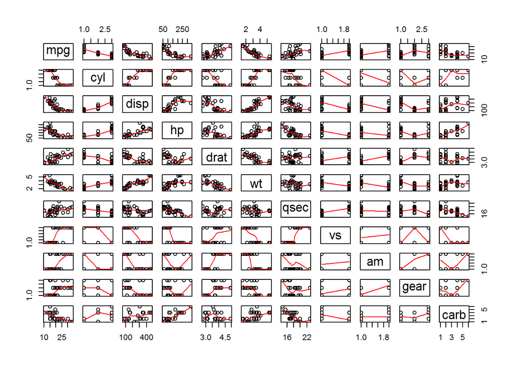

### Figure 2 - Box plot of mpg vs transmission type

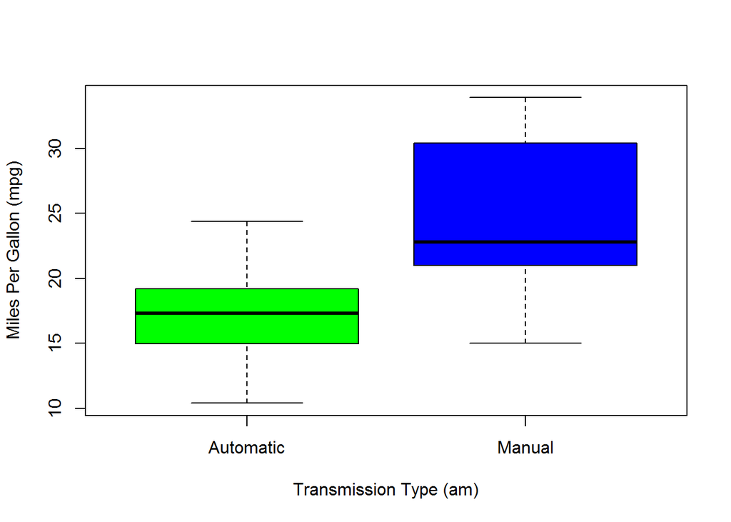

### Figure 3 - Residual Plots

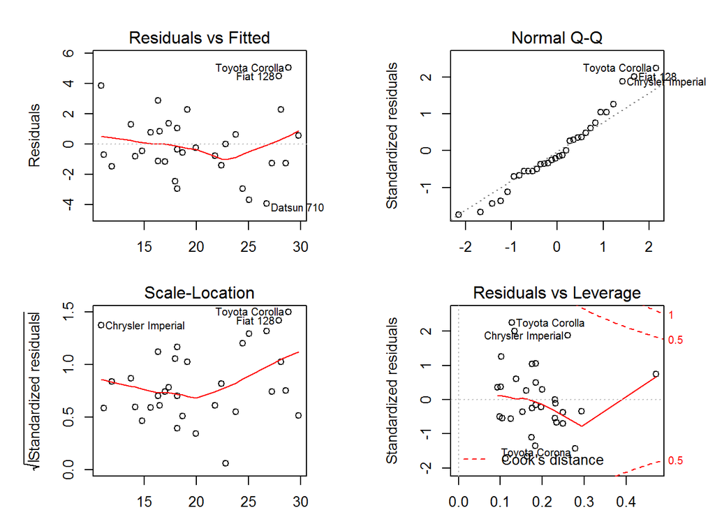